# Notebook

## Iterate like a grandmaster

**Note**: If you're fairly new to Kaggle, NLP, or Transformers, I strongly recommend you read my [Getting Started](https://www.kaggle.com/code/jhoward/getting-started-with-nlp-for-absolute-beginners) notebook first, and then come back to this one.

There's a lot of impressive notebooks around on Kaggle, but they often fall into one of two categories:

- Exploratory Data Analysis (EDA) notebooks with lots of pretty charts, but not much focus on understanding the key issues that will make a difference in the competition
- Training/inference notebooks with little detail about *why* each step was chosen.

In this notebook I'll try to give a taste of how a competitions grandmaster might tackle the [U.S. Patent Phrase to Phrase Matching](https://www.kaggle.com/competitions/us-patent-phrase-to-phrase-matching/) competition. The focus generally should be two things:

1. Creating an effective validation set
2. Iterating rapidly to find changes which improve results on the validation set.

If you can do these two things, then you can try out lots of experiments and find what works, and what doesn't. Without these two things, it will be nearly impossible to do well in a Kaggle competition (and, indeed, to create highly accurate models in real life!)

I will show a couple of different ways to create an appropriate validation set, and will explain how to expand them into an appropriate cross-validation system. I'll use just plain HuggingFace Transformers for everything, and will keep the code concise and simple. The more code you have, the more you have to maintain, and the more chances there are to make mistakes. So keep it simple!

OK, let's get started...

It's nice to be able to run things locally too, to save your Kaggle GPU hours, so set a variable to make it easy to see where we are, and download what we need:

```python
!pip install kaggle
```

```python
from pathlib import Path
import os

iskaggle = os.environ.get('KAGGLE_KERNEL_RUN_TYPE', '')
if iskaggle:
    !pip install -Uqq fastai
else:
    import zipfile,kaggle
    path = Path('us-patent-phrase-to-phrase-matching')
    kaggle.api.competition_download_cli(str(path))
    zipfile.ZipFile(f'{path}.zip').extractall(path)
```

```
us-patent-phrase-to-phrase-matching.zip: Skipping, found more recently modified local copy (use --force to force download)
```

A lot of the basic imports you'll want (`np`, `pd`, `plt`, etc) are provided by fastai, so let's grab them in one line:

```python
from fastai.imports import *
```

## Import and EDA

Set a path to our data. Use `pathlib.Path` because it makes everything so much easier, and make it work automatically regardless if you're working on your own PC or on Kaggle!

```python
if iskaggle: path = Path('us-patent-phrase-to-phrase-matching')
path.ls()
```

```
(#3) [Path('us-patent-phrase-to-phrase-matching/test.csv'),Path('us-patent-phrase-to-phrase-matching/train.csv'),Path('us-patent-phrase-to-phrase-matching/sample_submission.csv')]
```

```python
!ls
```

```
iterate-like-a-grandmaster.ipynb        us-patent-phrase-to-phrase-matching.zip
notes.md                                utilidades
us-patent-phrase-to-phrase-matching
```

Let's look at the training set:

```python
#import pandas as pd

# Aumentar el ancho máximo de las columnas (por ejemplo, 1000)
#pd.set_option('display.max_colwidth', 1000)
# Mostrar todas las filas
#pd.set_option('display.max_rows', None)

# Mostrar todas las columnas
pd.set_option('display.max_columns', None)
```

```python
df = pd.read_csv(path/'train.csv')
df.head()
```

|  | id | anchor | target | context | score |
| --- | --- | --- | --- | --- | --- |
| 0 | 37d61fd2272659b1 | abatement | abatement of pollution | A47 | 0.50 |
| 1 | 7b9652b17b68b7a4 | abatement | act of abating | A47 | 0.75 |
| 2 | 36d72442aefd8232 | abatement | active catalyst | A47 | 0.25 |
| 3 | 5296b0c19e1ce60e | abatement | eliminating process | A47 | 0.50 |
| 4 | 54c1e3b9184cb5b6 | abatement | forest region | A47 | 0.00 |

```python
!ls {path}
```

```
huggingface/tokenizers: The current process just got forked, after parallelism has already been used. Disabling parallelism to avoid deadlocks...
To disable this warning, you can either:
	- Avoid using `tokenizers` before the fork if possible
	- Explicitly set the environment variable TOKENIZERS_PARALLELISM=(true | false)
sample_submission.csv test.csv              train.csv
```

```python
df.describe(include='object')
```

|  | id | anchor | target | context |
| --- | --- | --- | --- | --- |
| count | 36473 | 36473 | 36473 | 36473 |
| unique | 36473 | 733 | 29340 | 106 |
| top | 37d61fd2272659b1 | component composite coating | composition | H01 |
| freq | 1 | 152 | 24 | 2186 |

# a partir de aquí sigo la explicación de Jeremy Howard en el video "Lesson 4"

```python
df['input'] = 'TEXT1: ' + df.context + '; TEXT2: ' + df.target + '; ANC1: ' + df.anchor
```

```python
df.input.head()
```

```
0    TEXT1: A47; TEXT2: abatement of pollution; ANC1: abatement
1            TEXT1: A47; TEXT2: act of abating; ANC1: abatement
2           TEXT1: A47; TEXT2: active catalyst; ANC1: abatement
3       TEXT1: A47; TEXT2: eliminating process; ANC1: abatement
4             TEXT1: A47; TEXT2: forest region; ANC1: abatement
Name: input, dtype: object
```

```python
!pip install datasets
```

```python
from datasets import Dataset, DatasetDict
ds = Dataset.from_pandas(df)
```

```python
model_nm = 'microsoft/deberta-v3-small'
```

# AoutoTokenizer creará un tokenizador apropiado para un modelo dado

```python
from transformers import AutoModelForSequenceClassification, AutoTokenizer
tokz = AutoTokenizer.from_pretrained(model_nm)
```

```
Special tokens have been added in the vocabulary, make sure the associated word embeddings are fine-tuned or trained.
Special tokens have been added in the vocabulary, make sure the associated word embeddings are fine-tuned or trained.
```

```python
tokz.tokenize("inorganic photoconductor drum")
```

```
['▁inorganic', '▁photo', 'conductor', '▁drum']
```

```python
tokz.tokenize("Hola Mundo, estoy aprendiendo con Jeremy fastai en 2024 verano!")
```

```
['▁Hola',
 '▁Mundo',
 ',',
 '▁esto',
 'y',
 '▁a',
 'prendi',
 'endo',
 '▁con',
 '▁Jeremy',
 '▁fast',
 'ai',
 '▁en',
 '▁2024',
 '▁vera',
 'no',
 '!']
```

```python
!pip install nbdev
```

[output not shown]

```python
?tok_func
```

```
Object `tok_func` not found.
```

```python
def tok_func(x): return tokz(x["input"])
```

```python
tok_ds =ds.map(tok_func,batched=True)
```

```python
row = tok_ds[0]
row["input"], row['input_ids']
```

```
('TEXT1: A47; TEXT2: abatement of pollution; ANC1: abatement',
 [1,
  54453,
  435,
  294,
  336,
  5753,
  346,
  54453,
  445,
  294,
  47284,
  265,
  6435,
  346,
  23702,
  435,
  294,
  47284,
  2])
```

```python
tokz.vocab['▁drum']
```

```
8263
```

```python
tok_ds = tok_ds.rename_columns({'score':'labels'})
```

```python
tok_ds
```

```
Dataset({
    features: ['id', 'anchor', 'target', 'context', 'labels', 'input', 'input_ids', 'token_type_ids', 'attention_mask'],
    num_rows: 36473
})
```

# Coheficioente de correlación Pearson

```python
from sklearn.datasets import fetch_california_housing
```

```python
housing = fetch_california_housing(as_frame=True)
housing = housing['data'].join(housing['target']).sample(1000,random_state=52)
housing.head(7)
```

|  | MedInc | HouseAge | AveRooms | AveBedrms | Population | AveOccup | Latitude | Longitude | MedHouseVal |
| --- | --- | --- | --- | --- | --- | --- | --- | --- | --- |
| 7506 | 3.0550 | 37.0 | 5.152778 | 1.048611 | 729.0 | 5.062500 | 33.92 | -118.28 | 1.054 |
| 4720 | 3.0862 | 35.0 | 4.697897 | 1.055449 | 1159.0 | 2.216061 | 34.05 | -118.37 | 3.453 |
| 12888 | 2.5556 | 24.0 | 4.864905 | 1.129222 | 1631.0 | 2.395007 | 38.66 | -121.35 | 1.057 |
| 13344 | 3.0057 | 32.0 | 4.212687 | 0.936567 | 1378.0 | 5.141791 | 34.05 | -117.64 | 0.969 |
| 7173 | 1.9083 | 42.0 | 3.888554 | 1.039157 | 1535.0 | 4.623494 | 34.05 | -118.19 | 1.192 |
| 1727 | 0.7403 | 37.0 | 4.491429 | 1.148571 | 1046.0 | 2.988571 | 37.96 | -122.37 | 0.686 |
| 6914 | 5.2851 | 36.0 | 6.138571 | 1.024286 | 2038.0 | 2.911429 | 33.94 | -117.98 | 2.588 |

```python
np.set_printoptions(precision=2, suppress=True)
np.corrcoef(housing, rowvar=False)
```

```
array([[ 1.  , -0.12,  0.43, -0.08,  0.01, -0.07, -0.12,  0.04,  0.68],
       [-0.12,  1.  , -0.17, -0.06, -0.31,  0.  ,  0.03, -0.13,  0.12],
       [ 0.43, -0.17,  1.  ,  0.76, -0.09, -0.07,  0.12, -0.03,  0.21],
       [-0.08, -0.06,  0.76,  1.  , -0.08, -0.07,  0.09,  0.  , -0.04],
       [ 0.01, -0.31, -0.09, -0.08,  1.  ,  0.16, -0.15,  0.13,  0.  ],
       [-0.07,  0.  , -0.07, -0.07,  0.16,  1.  , -0.16,  0.17, -0.27],
       [-0.12,  0.03,  0.12,  0.09, -0.15, -0.16,  1.  , -0.93, -0.16],
       [ 0.04, -0.13, -0.03,  0.  ,  0.13,  0.17, -0.93,  1.  , -0.03],
       [ 0.68,  0.12,  0.21, -0.04,  0.  , -0.27, -0.16, -0.03,  1.  ]])
```

```python
!pip install seaborn
```

[output not shown]

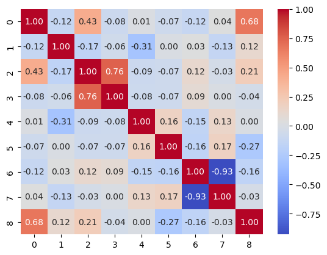

```python
import seaborn as sns
import matplotlib.pyplot as plt

corr_matrix = np.corrcoef(housing, rowvar=False)
sns.heatmap(corr_matrix, annot=True, fmt=".2f", cmap="coolwarm")
plt.show()
```

```python
# Si 'housing' es un DataFrame de pandas:
variables = housing.columns
print(variables)
```

```
Index(['MedInc', 'HouseAge', 'AveRooms', 'AveBedrms', 'Population', 'AveOccup',
       'Latitude', 'Longitude', 'MedHouseVal'],
      dtype='object')
```

## Esto funcionará bien cuando obtengamos un montón de valores a la vez

```python
np.corrcoef(housing.MedInc, housing.MedHouseVal)
```

```
array([[1.  , 0.68],
       [0.68, 1.  ]])
```

## Cuando queremos obtener un único valor de dos variables dadas lo hacemos con la siguiente función

```python
def corr(x,y): return np.corrcoef(x,y)[0][1]
corr(housing.MedInc, housing.MedHouseVal)
```

```
0.6760250732906014
```

```python
def show_corr(df,a,b):
    x,y = df[a],df[b]
    plt.scatter(x,y, alpha=0.5, s=4)
    plt.title(f'{a} vs {b}; r:{corr(x,y):2f}')
```

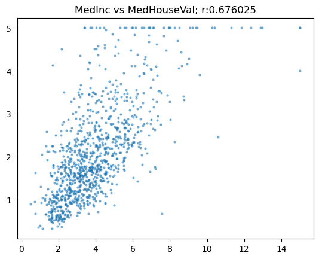

```python
show_corr(housing,'MedInc','MedHouseVal')
```

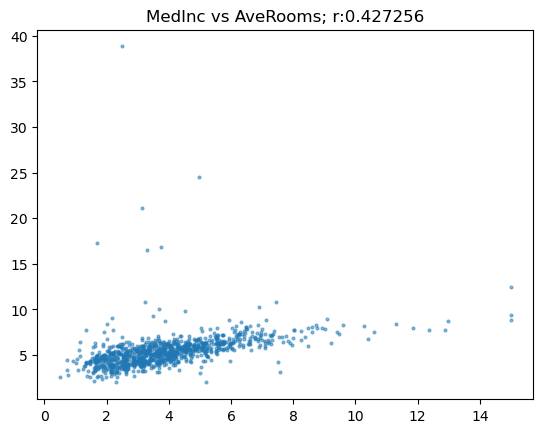

```python
show_corr(housing, 'MedInc','AveRooms')
```

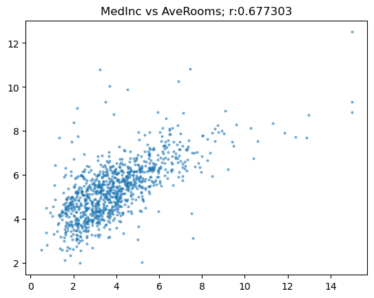

```python
subset = housing[housing.AveRooms<15]
show_corr(subset,'MedInc','AveRooms')
```

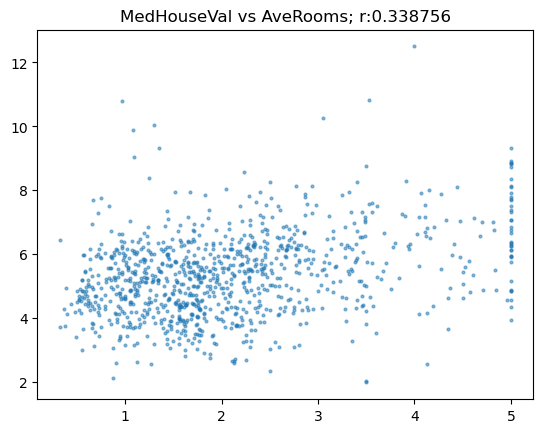

```python
show_corr(subset, 'MedHouseVal', 'AveRooms')
```

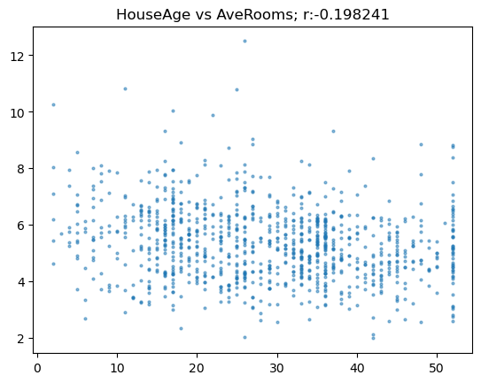

```python
show_corr(subset, 'HouseAge', 'AveRooms')
```

```python
def corr_d(eval_pred): return {'pearson':corr(*eval_pred) }
```

# Entrenamos nuestro modelo

## Para entrenar un modelo con Transformers necesitaremos esto:

```python
from transformers import TrainingArguments, Trainer
```

## Elije un tamaño del lote que se ajuste a nuestra GPU y un pequeño numero de epochs para poder arrancar el experimento rápidamente

```python
bs = 128
epochs = 4
```

### El hiperparámetro más importante es el de ratio de apredizaje.fastai proporciona un buscador de tasas de aprendizaje para ayudarle a averiguarlo, pero Transformers no, así que sólo tienes que usar prueba y error. La idea es encontrar el valor más grande que tú puedas, pero que no resulte un entrenamiento fallido.

```python
lr = 8e-5
```

```python
!pip install transformers[torch]
```

[output not shown]

```python
!pip install accelerate -U
```

[output not shown]

```python
args = TrainingArguments('outputs',learning_rate=lr, warmup_ratio=0.1,lr_scheduler_type='cosine',fp16 = True,
evaluation_strategy= "epoch",per_device_train_batch_size=bs, per_device_eval_batch_size=bs*2,
num_train_epochs= epochs, weight_decay=0.01, report_to='none')
```

[output not shown]

We can now create a tokenizer for this model. Note that pretrained models assume that text is tokenized in a particular way. In order to ensure that your tokenizer matches your model, use the `AutoTokenizer`, passing in your model name.

```python
def get_trainer(dds):
    args = TrainingArguments('outputs', learning_rate=lr, warmup_ratio=0.1, lr_scheduler_type='cosine', fp16=True,
        evaluation_strategy="epoch", per_device_train_batch_size=bs, per_device_eval_batch_size=bs*2,
        num_train_epochs=epochs, weight_decay=wd, report_to='none')
    model = AutoModelForSequenceClassification.from_pretrained(model_nm, num_labels=1)
    return Trainer(model, args, train_dataset=dds['train'], eval_dataset=dds['test'],
                   tokenizer=tokz, compute_metrics=corr)
```

```python
args = TrainingArguments('outputs', learning_rate=lr, warmup_ratio=0.1, lr_scheduler_type='cosine', fp16=True,
    evaluation_strategy="epoch", per_device_train_batch_size=bs, per_device_eval_batch_size=bs*2,
    num_train_epochs=epochs, weight_decay=wd, report_to='none')
```

We can now create our model, and `Trainer`, which is a class which combines the data and model together (just like `Learner` in fastai):

```python
model = AutoModelForSequenceClassification.from_pretrained(model_nm, num_labels=1)
trainer = Trainer(model, args, train_dataset=dds['train'], eval_dataset=dds['test'],
               tokenizer=tokz, compute_metrics=corr)
```

Let's train our model!

```python
trainer.train();
```

[856/856 04:19, Epoch 4/4]

| Epoch | Training Loss | Validation Loss | Pearson |
| --- | --- | --- | --- |
| 1 | No log | 0.025167 | 0.798359 |
| 2 | No log | 0.025149 | 0.803286 |
| 3 | 0.035300 | 0.024344 | 0.815202 |
| 4 | 0.035300 | 0.024549 | 0.815378 |

## Improving the model

Iteration speed is critical, so we need to quickly be able to try different data processing and trainer parameters. So let's create a function to quickly apply tokenization and create our `DatasetDict`:

```python
def get_dds(df):
    ds = Dataset.from_pandas(df).rename_column('score', 'label')
    tok_ds = ds.map(tok_func, batched=True, remove_columns=inps+('inputs','id','section'))
    return DatasetDict({"train":tok_ds.select(trn_idxs), "test": tok_ds.select(val_idxs)})
```

...and also a function to create a `Trainer`:

```python
def get_model(): return AutoModelForSequenceClassification.from_pretrained(model_nm, num_labels=1)

def get_trainer(dds, model=None):
    if model is None: model = get_model()
    args = TrainingArguments('outputs', learning_rate=lr, warmup_ratio=0.1, lr_scheduler_type='cosine', fp16=True,
        evaluation_strategy="epoch", per_device_train_batch_size=bs, per_device_eval_batch_size=bs*2,
        num_train_epochs=epochs, weight_decay=wd, report_to='none')
    return Trainer(model, args, train_dataset=dds['train'], eval_dataset=dds['test'],
                   tokenizer=tokz, compute_metrics=corr)
```

Let's now try out some ideas...

Perhaps using the special separator character isn't a good idea, and we should use something we create instead. Let's see if that makes things better. First we'll change the separator and create the `DatasetDict`:

```python
sep = " [s] "
df['inputs'] = df.context + sep + df.anchor + sep + df.target
dds = get_dds(df)
```

...and create and train a model.

```python
get_trainer(dds).train()
```

[856/856 04:29, Epoch 4/4]

| Epoch | Training Loss | Validation Loss | Pearson |
| --- | --- | --- | --- |
| 1 | No log | 0.024909 | 0.797869 |
| 2 | No log | 0.024800 | 0.812953 |
| 3 | 0.031600 | 0.024418 | 0.818292 |
| 4 | 0.031600 | 0.024037 | 0.819089 |

```
TrainOutput(global_step=856, training_loss=0.023822079752093165, metrics={'train_runtime': 269.6383, 'train_samples_per_second': 405.833, 'train_steps_per_second': 3.175, 'total_flos': 582160588599300.0, 'train_loss': 0.023822079752093165, 'epoch': 4.0})
```

That's looking quite a bit better, so we'll keep that change.

Often changing to lowercase is helpful. Let's see if that helps too:

```python
df['inputs'] = df.inputs.str.lower()
dds = get_dds(df)
get_trainer(dds).train()
```

[856/856 04:34, Epoch 4/4]

| Epoch | Training Loss | Validation Loss | Pearson |
| --- | --- | --- | --- |
| 1 | No log | 0.025170 | 0.798002 |
| 2 | No log | 0.024433 | 0.815301 |
| 3 | 0.031500 | 0.024575 | 0.818443 |
| 4 | 0.031500 | 0.024150 | 0.818868 |

```
TrainOutput(global_step=856, training_loss=0.023811190484840178, metrics={'train_runtime': 274.7918, 'train_samples_per_second': 398.222, 'train_steps_per_second': 3.115, 'total_flos': 582160588599300.0, 'train_loss': 0.023811190484840178, 'epoch': 4.0})
```

That one is less clear. We'll keep that change too since most times I run it, it's a little better.

## Special tokens

What if we made the patent section a special token? Then potentially the model might learn to recognize that different sections need to be handled in different ways. To do that, we'll use, e.g. `[A]` for section A. We'll then add those as special tokens:

```python
df['sectok'] = '[' + df.section + ']'
sectoks = list(df.sectok.unique())
tokz.add_special_tokens({'additional_special_tokens': sectoks})
```

```
8
```

We concatenate the section token to the start of our inputs:

```python
df['inputs'] = df.sectok + sep + df.context + sep + df.anchor.str.lower() + sep + df.target
dds = get_dds(df)
```

Since we've added more tokens, we need to resize the embedding matrix in the model:

```python
model = get_model()
model.resize_token_embeddings(len(tokz))
```

```
Embedding(128009, 768)
```

Now we're ready to train:

```python
trainer = get_trainer(dds, model=model)
trainer.train()
```

[856/856 04:55, Epoch 4/4]

| Epoch | Training Loss | Validation Loss | Pearson |
| --- | --- | --- | --- |
| 1 | No log | 0.024835 | 0.797996 |
| 2 | No log | 0.024412 | 0.812386 |
| 3 | 0.031800 | 0.024019 | 0.820914 |
| 4 | 0.031800 | 0.024220 | 0.820187 |

```
TrainOutput(global_step=856, training_loss=0.023861238889605084, metrics={'train_runtime': 296.1519, 'train_samples_per_second': 369.5, 'train_steps_per_second': 2.89, 'total_flos': 695409809982180.0, 'train_loss': 0.023861238889605084, 'epoch': 4.0})
```

It looks like we've made another bit of an improvement!

There's plenty more things you could try. Here's some thoughts:

- Try a model pretrained on legal vocabulary. E.g. how about [BERT for patents](https://huggingface.co/anferico/bert-for-patents)?
- You'd likely get better results by using a sentence similarity model. Did you know that there's a [patent similarity model](https://huggingface.co/AI-Growth-Lab/PatentSBERTa) you could try?
- You could also fine-tune any HuggingFace model using the full patent database (which is provided in BigQuery), before applying it to this dataset
- Replace the patent context field with the description of that context provided by the patent office
- ...and try out your own ideas too!

Before submitting a model, retrain it on the full dataset, rather than just the 75% training subset we've used here. Create a function like the ones above to make that easy for you!"

## Cross-validation

```python
n_folds = 4
```

Once you've gotten the low hanging fruit, you might want to use cross-validation to see the impact of minor changes. This time we'll use StratifiedGroupKFold, partly just to show a different approach to before, and partly because it will give us slightly better balanced datasets.

```python
from sklearn.model_selection import StratifiedGroupKFold
cv = StratifiedGroupKFold(n_splits=n_folds)
```

Here's how to split the data frame into `n_folds` groups, with non-overlapping anchors and matched scores, after randomly shuffling the rows:

```python
df = df.sample(frac=1, random_state=42)
scores = (df.score*100).astype(int)
folds = list(cv.split(idxs, scores, df.anchor))
folds
```

```
[(array([    0,     1,     2, ..., 36469, 36471, 36472]),
  array([    8,    13,    14, ..., 36453, 36464, 36470])),
 (array([    0,     1,     5, ..., 36470, 36471, 36472]),
  array([    2,     3,     4, ..., 36459, 36461, 36462])),
 (array([    1,     2,     3, ..., 36467, 36470, 36472]),
  array([    0,     7,    11, ..., 36468, 36469, 36471])),
 (array([    0,     2,     3, ..., 36469, 36470, 36471]),
  array([    1,     5,     9, ..., 36465, 36467, 36472]))]
```

We can now create a little function to split into training and validation sets based on a fold:

```python
def get_fold(folds, fold_num):
    trn,val = folds[fold_num]
    return DatasetDict({"train":tok_ds.select(trn), "test": tok_ds.select(val)})
```

Let's try it out:

```python
dds = get_fold(folds, 0)
dds
```

```
DatasetDict({
    train: Dataset({
        features: ['label', 'input_ids', 'token_type_ids', 'attention_mask'],
        num_rows: 27346
    })
    test: Dataset({
        features: ['label', 'input_ids', 'token_type_ids', 'attention_mask'],
        num_rows: 9127
    })
})
```

We can now pass this into `get_trainer` as we did before. If we have, say, 4 folds, then doing that for each fold will give us 4 models, and 4 sets of predictions and metrics. You could ensemble the 4 models to get a stronger model, and can also average the 4 metrics to get a more accurate assessment of your model. Here's how to get the final epoch metrics from a trainer:

```python
metrics = [o['eval_pearson'] for o in trainer.state.log_history if 'eval_pearson' in o]
metrics[-1]
```

```
0.8201874392079798
```

I hope you've found this a helpful guide to improving your results in this competition - and on Kaggle more generally! If you like it, please remember to give it an upvote, and don't hesitate to add a comment if you have any questions or thoughts to add. And if the ideas here are helpful to you in creating your models, I'd really appreciate a link back to this notebook or a comment below to let me know what helped.

```python
# Reemplaza 'archivo.csv' con la ruta de tu archivo CSV
ruta_del_archivo = 'us-patent-phrase-to-phrase-matching/test.csv'

# Cargar el archivo CSV en un DataFrame
df1 = pd.read_csv(ruta_del_archivo)

# Mostrar las primeras filas del DataFrame para verificar que se ha cargado correctamente
print(df.head())
```

[output not shown]

```python
pd.open(ruta_del_archivo)
```

[output not shown]

```python
print(df1)
```

```
                  id                       anchor  \
0   4112d61851461f60                     opc drum
1   09e418c93a776564              adjust gas flow
2   36baf228038e314b               lower trunnion
3   1f37ead645e7f0c8                cap component
4   71a5b6ad068d531f           neural stimulation
5   474c874d0c07bd21                     dry corn
6   442c114ed5c4e3c9          tunneling capacitor
7   b8ae62ea5e1d8bdb      angular contact bearing
8   faaddaf8fcba8a3f  produce liquid hydrocarbons
9   ae0262c02566d2ce             diesel fuel tank
10  a8808e31641e856d            chemical activity
11  16ae4b99d3601e60         transmit to platform
12  25c555ca3d5a2092                  oil tankers
13  5203a36c501f1b7c            generate in layer
```

[output cut: 60 more lines]